##Peer Graded Assignment Milestone. **Shivangi Mehta** **Date–11/7/2021**

**Introduction**

This is the project of Swiftkey company who invent digital Keys on Cell Phone. The purpose of this project is to identify the most frequent words used while texting using mobile phone. We are going to analysis this by using Blogs, twitter, News data set provided by Coursera in Data Science Specialization.

**TASK 1**

**Getting and Cleaning Data**

**Tasks to accomplish**

TASK 1.1## Tokenization - identifying appropriate tokens such as words, punctuation, and numbers. Writing a function that takes a file as input and returns a tokenized version of it.

TASK 1.2## Profanity filtering - removing profanity and other words you do not want to predict.

**Criteria**

Here I have followed below Instruction from Coursera.

1.The link lead to an HTML page describing the exploratory analysis of the training data set.

2.summaries of the three files. Word counts, line counts and basic data tables.

3.The data scientist made basic plots, such as histograms to illustrate features of the data.

4.The report written in a brief.

**load All Require packages**

```r
library(dplyr)
```

```r
library(ggplot2)
require(readtext)
library(sqldf)
library(stringi)
library(quanteda)
```

**Load the Data**

```r
if(!file.exists("./data")){dir.create("./data")}
fileUrl <- "https://d396qusza40orc.cloudfront.net/dsscapstone/dataset/Coursera-SwiftKey.zip"
download.file(fileUrl,destfile="./data/Coursera-SwiftKey.zip")
```

**unzipped the file**

```r
unzip <- unzip(zipfile="./data/Coursera-SwiftKey.zip",exdir="./data")
unzip
```

```
##  [1] "./data/final/de_DE/de_DE.twitter.txt"
##  [2] "./data/final/de_DE/de_DE.blogs.txt"
##  [3] "./data/final/de_DE/de_DE.news.txt"
##  [4] "./data/final/ru_RU/ru_RU.blogs.txt"
##  [5] "./data/final/ru_RU/ru_RU.news.txt"
##  [6] "./data/final/ru_RU/ru_RU.twitter.txt"
##  [7] "./data/final/en_US/en_US.twitter.txt"
##  [8] "./data/final/en_US/en_US.news.txt"
##  [9] "./data/final/en_US/en_US.blogs.txt"
## [10] "./data/final/fi_FI/fi_FI.news.txt"
## [11] "./data/final/fi_FI/fi_FI.blogs.txt"
## [12] "./data/final/fi_FI/fi_FI.twitter.txt"
```

**Checking Data Connection by creating Summary**

```r
con <- file("./data/final/en_US/en_US.twitter.txt", "r")
twittertxt <- readLines(con,encoding = "UTF-8", skipNul = TRUE )
con1 <- file("./data/final/en_US/en_US.blogs.txt", "r")
blogstxt <- readLines(con1, encoding = "UTF-8", skipNul = TRUE)
con2 <- file("./data/final/en_US/en_US.news.txt", "r")
newstxt <- readLines(con, encoding = "UTF-8", skipNul = TRUE)
close(con)
```

```r
sizeTwitter <- file.info("./data/final/en_US/en_US.twitter.txt")$size / 1024
sizeblogs <- file.info("./data/final/en_US/en_US.blogs.txt")$size / 1024
sizenews <- file.info("./data/final/en_US/en_US.news.txt")$size / 1024
wordsTwitter <- stri_count_words("./data/final/en_US/en_US.twitter.txt")
wordsblogs <- stri_count_words("./data/final/en_US/en_US.blogs.txt")
wordsnews <- stri_count_words("./data/final/en_US/en_US.news.txt")
data.frame(Source = c("Twitter", "News", "Blogs"),
           SizeMB = c(sizeTwitter,sizeblogs,sizenews),
           NoofLines = c(length(twittertxt),length(blogstxt), length(newstxt)),
           NoOfWords = c(sum(wordsTwitter),sum(wordsblogs), sum(wordsnews)))
```

```
##    Source   SizeMB NoofLines NoOfWords
## 1 Twitter 163188.8   2360148         4
## 2    News 205234.4    899288         4
## 3   Blogs 200988.2         0         4
```

Since this is the large set of data, this is difficult for us to load all of those within limited RAM memory in personal computer. Therefore, I am collecting Sample out of it as below to complete my analysis.

**Sampling**

```r
set.seed(1288)
twitter_sample <- sample(twittertxt, length(twittertxt)*0.01, replace = FALSE)
blogs_sample <- sample(blogstxt, length(blogstxt)*0.01, replace = FALSE)
news_sample <- sample(newstxt, length(newstxt)*0.01, replace = FALSE)
Sample_data <- c(twitter_sample, blogs_sample, news_sample)
```

**TASK 2**

I am removing those Text which I don’t want to analyis.

##Clean Data more in Dept.

```r
##Creating Corpus.

##From the above step we got our Corpus.Lets clean data by removing punctuation, remove the numbers and the common english stopwords.

library(tm)
corpus <- VCorpus(VectorSource(list(Sample_data)))

corpus <- tm_map(corpus, content_transformer(tolower))
corpus <- tm_map(corpus, removePunctuation)
corpus <- tm_map(corpus, removeNumbers)
corpus <- tm_map(corpus, removeWords, stopwords("english"))

for (j in seq(corpus)) {
  corpus[[j]] <- gsub("<.*>", " ", corpus[[j]])
  corpus[[j]] <- gsub("\\b[[:alnum:]]{20,}\\b", " ", corpus[[j]], perl=T)
  corpus[[j]] <- gsub("[[:punct:]]", " ", corpus[[j]])
}
corpus <- tm_map(corpus, PlainTextDocument)
```

##We also want to remove Profanity words to do analysis.I am using googlebad words dictionary.

```r
url <- "https://storage.googleapis.com/google-code-archive-downloads/v2/code.google.com/badwordslist/badwords.txt"
if(!file.exists("./data")){dir.create("./data")}
download.file(url,destfile="./data/badwords.txt")
badwords <- read.delim("./data/badwords.txt", sep = ":", header = FALSE)
badwords <- badwords[,1]
badwords <- removeWords(badwords[[458]], stopwords("english"))
corpus <- tm_map(corpus, stripWhitespace)
```

```r
data_sample_df <- tibble::tibble(line = 1:length(Sample_data), text = Sample_data)
```

```r
##Let create a plot for Unigram.

UnigramFreq <- data_sample_df %>%
    unnest_tokens(unigram, text, token = "ngrams", n = 3) %>%
    separate(unigram, c("word1"), sep = " ",
             extra = "drop", fill = "right") %>%
    filter(!word1 %in% stop_words$word) %>%
    unite(unigram, word1, sep = " ") %>%
    count(unigram, sort = TRUE)
```

```
## Error in unite(., unigram, word1, sep = " "): could not find function "unite"
```

```r
ggplot(head(UnigramFreq,15), aes(reorder(unigram,n), n)) +
    geom_bar(stat="identity") + coord_flip() +
    xlab("Unigrams") + ylab("Frequency") +
    ggtitle("Most frequent unigrams")
```

[output not shown]

[output not shown]

```
## Error in head(UnigramFreq, 15): object 'UnigramFreq' not found
```

**2. Plotting Bigram words frequency data**.

```r
##Lets Create Bigram Plot.

library(tidyr)
library(tidytext)

bigram_filtered <- data_sample_df %>%
  unnest_tokens(bigram, text, token= "ngrams", n=2) %>%
  separate(bigram, c("word1","word2"), sep=" ") %>%
  filter(!word1 %in% stop_words$word,
         !word2 %in% stop_words$word) %>%
  dplyr::count(word1, word2, sort=TRUE)


###Unite word 1 and word 2.

bigrams_united <- bigram_filtered %>%
  unite(bigram, word1, word2, sep=" ")
bigrams_united
```

```
## # A tibble: 85,409 x 2
##    bigram             n
##    <chr>          <int>
##  1 NA NA            112
##  2 happy birthday    97
##  3 social media      59
##  4 1 2               54
##  5 mother's day      37
##  6 rt rt             32
##  7 ice cream         31
##  8 mothers day       28
##  9 stay tuned        27
## 10 happy hour        26
## # ... with 85,399 more rows
```

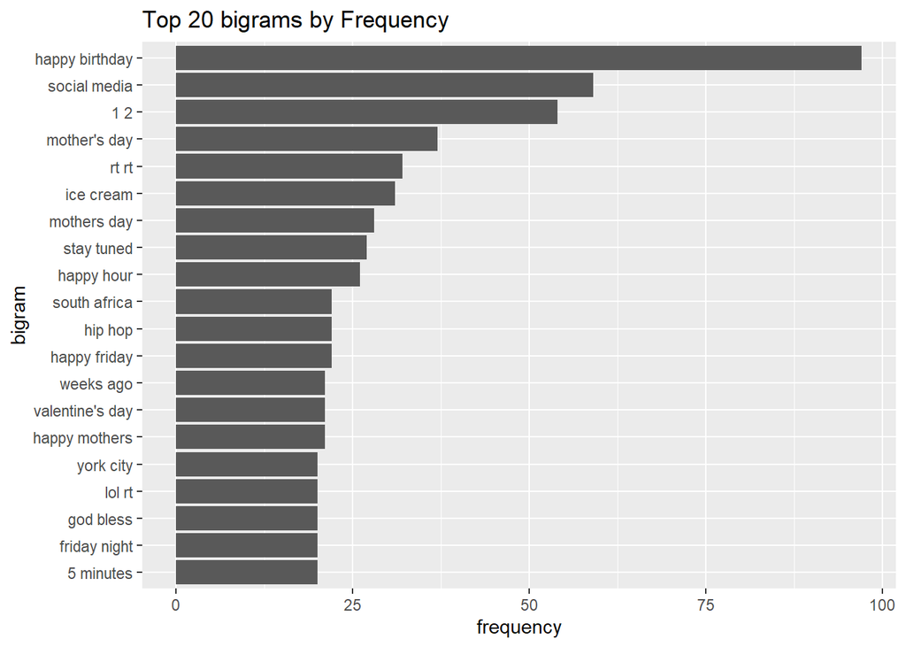

```r
###Remove NA NA Text which is in First column.

bigrams_united <- bigrams_united[-c(1),]

##Create ggplot after changing n to Frequency.

bigrams_united <- rename(bigrams_united, frequency = n)


ggplot(head(bigrams_united, 20),aes(x=reorder(bigram, frequency),y=frequency)) +
  geom_bar(stat = "Identity") + coord_flip() +
  theme(legend.title=element_blank()) +
  xlab("bigram") + ylab("frequency") +
  labs(title = "Top 20 bigrams by Frequency")
```

**3. Plotting Trigram Frequency.**

```r
trigram_filtered <- data_sample_df %>%
  unnest_tokens(trigram, text, token= "ngrams", n=3) %>%
  separate(trigram, c("word1","word2","word3"), sep=" ") %>%
  filter(!word1 %in% stop_words$word,
         !word2 %in% stop_words$word,
         !word3 %in% stop_words$word) %>%
  dplyr::count(word1, word2, word3, sort=TRUE)

###Unite word1, word2, word3.

trigrams_united <- trigram_filtered %>%
  unite(trigram, word1, word2, word3, sep=" ")
trigrams_united
```

```
## # A tibble: 35,099 x 2
##    trigram                     n
##    <chr>                   <int>
##  1 NA NA NA                  983
##  2 happy mothers day          21
##  3 happy mother's day         18
##  4 cinco de mayo              12
##  5 bismarck north dakota       9
##  6 1 2 cup                     8
##  7 amazon services llc         8
##  8 buffalo buffalo buffalo     7
##  9 dominos bismarck north      7
## 10 happy valentine's day       7
## # ... with 35,089 more rows
```

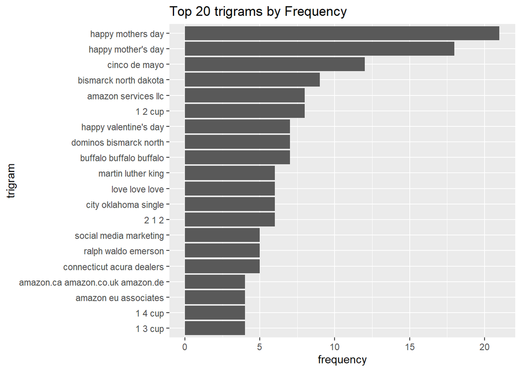

```r
##Remove NA NA Text.

trigrams_united <- trigrams_united[-c(1),]

##Lets Plot the Trigram frequency.

trigrams_united <- rename(trigrams_united, frequency = n)

ggplot(head(trigrams_united, 20),aes(x=reorder(trigram, frequency),y=frequency)) +
  geom_bar(stat = "Identity") + coord_flip() +
  theme(legend.title=element_blank()) +
  xlab("trigram") + ylab("frequency") +
  labs(title = "Top 20 trigrams by Frequency")
```